# Matchday 38

Arjun Chattoraj

8/2/2020

I will start by looking at a single matchday’s data.

I’ll start by using the most recent one, Matchday 38: Leicester 0 - 2 Manchester United. This match confirmed 3rd place and **Manchester United’s return to the Champions League for the 2020/21 season**!

# Packages

```r
library(readr)
library(dplyr)
```

```r
library(ggplot2)
```

# Loading the data

```r
md38 = read_csv("../data/38-Leicester City 0-2 Manchester United.csv")
names(md38)[length(md38)] = "Referee"
head(md38)
```

```
## # A tibble: 6 x 18
##   Timestamp `De Gea` Williams Maguire Lindelof `Wan-Bissaka` Matic Pogba
##   <chr>        <dbl>    <dbl>   <dbl>    <dbl>         <dbl> <dbl> <dbl>
## 1 2020/07/~        5        5       8        8             7     6     8
## 2 2020/07/~        6        6       6        8             6     6     6
## 3 2020/07/~        7        5       7        8             6     7     7
## 4 2020/07/~        7        8       8        8             8     8     7
## 5 2020/07/~        8        6       7        8             6     7     7
## 6 2020/07/~        7        6       6        8             7     6     6
## # ... with 10 more variables: Rashford <dbl>, Bruno <dbl>, Greenwood <dbl>,
## #   Martial <dbl>, Lingard <dbl>, `Team Performance` <dbl>, `Final
## #   Result` <dbl>, Ole <dbl>, Leicester <dbl>, Referee <chr>
```

```r
names(md38)
```

```
##  [1] "Timestamp"        "De Gea"           "Williams"         "Maguire"
##  [5] "Lindelof"         "Wan-Bissaka"      "Matic"            "Pogba"
##  [9] "Rashford"         "Bruno"            "Greenwood"        "Martial"
## [13] "Lingard"          "Team Performance" "Final Result"     "Ole"
## [17] "Leicester"        "Referee"
```

```r
nrow(md38)
```

```
## [1] 590
```

# Player Ratings

```r
playerRatings = sort(colMeans(md38[2:13], na.rm = T),decreasing = T)
data.frame(playerRatings)
```

```
##             playerRatings
## Lingard          8.875639
## Lindelof         8.374576
## Martial          7.476271
## Wan-Bissaka      7.098305
## Maguire          7.028814
## Bruno            6.954237
## De Gea           6.923729
## Pogba            6.877966
## Greenwood        6.837288
## Matic            6.815254
## Williams         6.811864
## Rashford         6.389831
```

# Distributions

## Best player

Jesse Lingard had the highest rating during this match. This was the first Premier League goal he has scored since Ole Gunnar Solskjaer’s first game in charge.

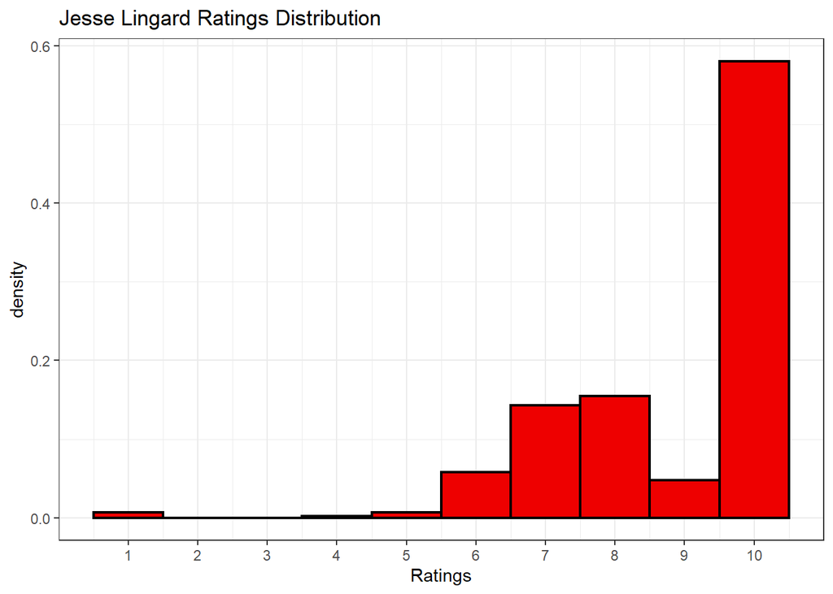

```r
md38 %>%
    ggplot(aes(x = Lingard)) +
    geom_histogram(aes(y = ..density..),binwidth = 1,
                   fill = "red2", color = "black", size = 0.8) +
    labs(title = "Jesse Lingard Ratings Distribution",
         x = "Ratings") +
    scale_x_continuous(breaks = 1:10) +
    theme_bw()
```

```r
round(prop.table(table(md38$Lingard)),3)
```

```
##
##     1     4     5     6     7     8     9    10
## 0.007 0.002 0.007 0.058 0.143 0.155 0.048 0.581
```

## Worst player

On the other hand we had Marcus Rashford. He’s been relatively quiet since the restart, but was the main man before his injury. I suspect that when the fans return to the stadium, their energy will spur him to better performances.

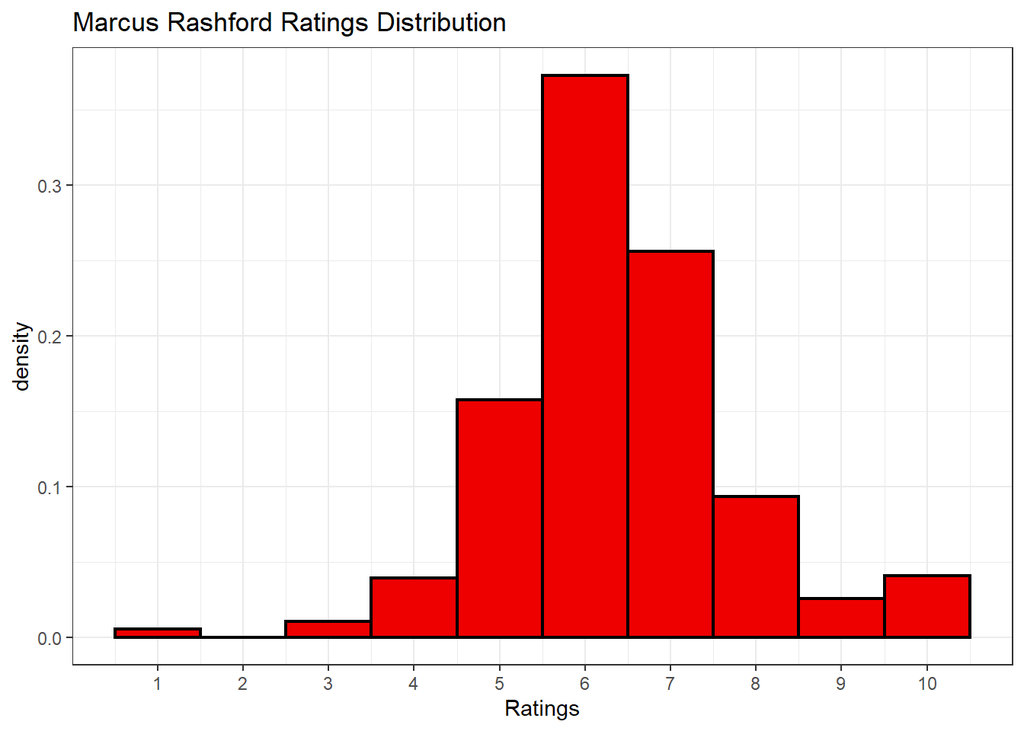

```r
md38 %>%
    ggplot(aes(x = Rashford)) +
    geom_histogram(aes(y = ..density..),binwidth = 1,
                   fill = "red2", color = "black", size = 0.8) +
    labs(title = "Marcus Rashford Ratings Distribution",
         x = "Ratings") +
    scale_x_continuous(breaks = 1:10) +
    theme_bw()
```

```r
round(prop.table(table(md38$Rashford)),3)
```

```
##
##     1     3     4     5     6     7     8     9    10
## 0.005 0.010 0.039 0.158 0.373 0.256 0.093 0.025 0.041
```

## The Manager

Solskjaer’s ratings were high because of the importance of the match with a positive result. He’s had a great season, with all his signings having positive effects on the team, allowing them to get 3rd.

```r
mean(md38$Ole, na.rm = T)
```

```
## [1] 8.181356
```

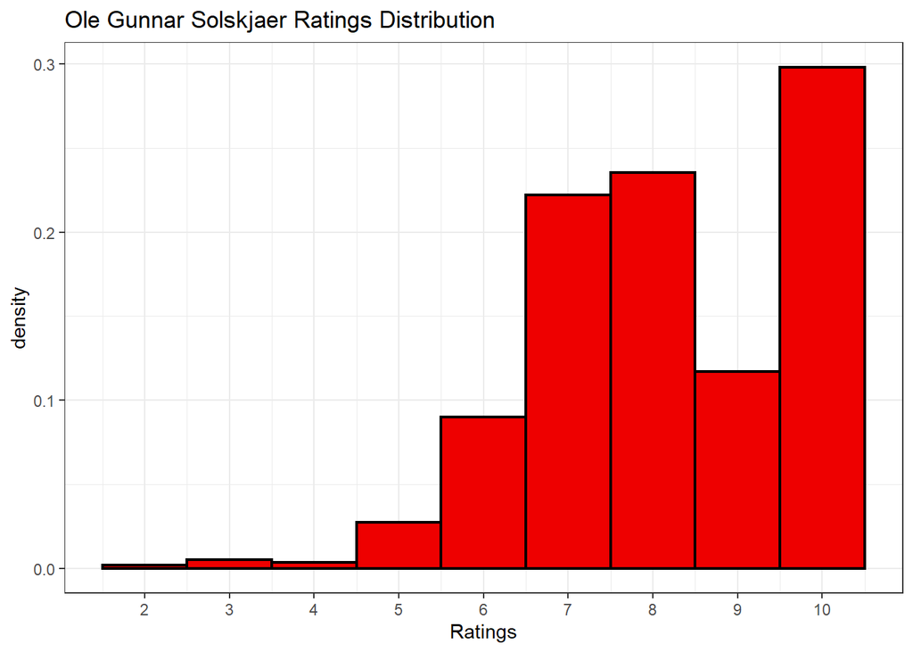

```r
md38 %>%
    ggplot(aes(x = Ole)) +
    geom_histogram(aes(y = ..density..),binwidth = 1,
                   fill = "red2", color = "black", size = 0.8) +
    labs(title = "Ole Gunnar Solskjaer Ratings Distribution",
         x = "Ratings") +
    scale_x_continuous(breaks = 1:10) +
    theme_bw()
```

## Team Performance

Mostly positive ratings. The victory makes sense for the ratings.

```r
mean(md38$`Team Performance`, na.rm = T)
```

```
## [1] 7.250847
```

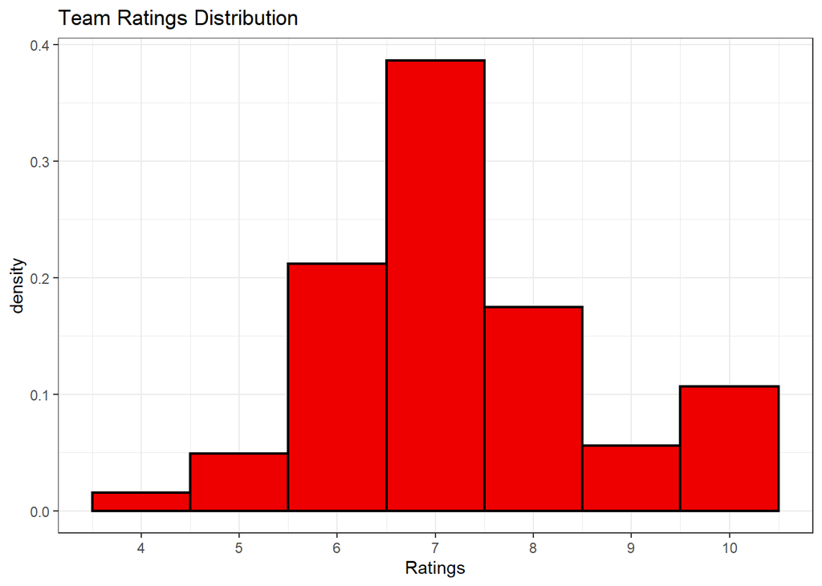

```r
md38 %>%
    ggplot(aes(x = `Team Performance`)) +
    geom_histogram(aes(y = ..density..),binwidth = 1,
                   fill = "red2", color = "black", size = 0.8) +
    labs(title = "Team Ratings Distribution",
         x = "Ratings") +
    scale_x_continuous(breaks = 1:10) +
    theme_bw()
```

# The Opposition

Leicester are a good team, but finished the season at 5th, despite being in 2nd or 3rd for large portions of the season. A solid 9-0 victory against Southampton and Jamie Vardy winning the golden boot does not reflect the calamitous drop in form following the resumption.

```r
mean(md38$Leicester, na.rm = T)
```

```
## [1] 5.449153
```

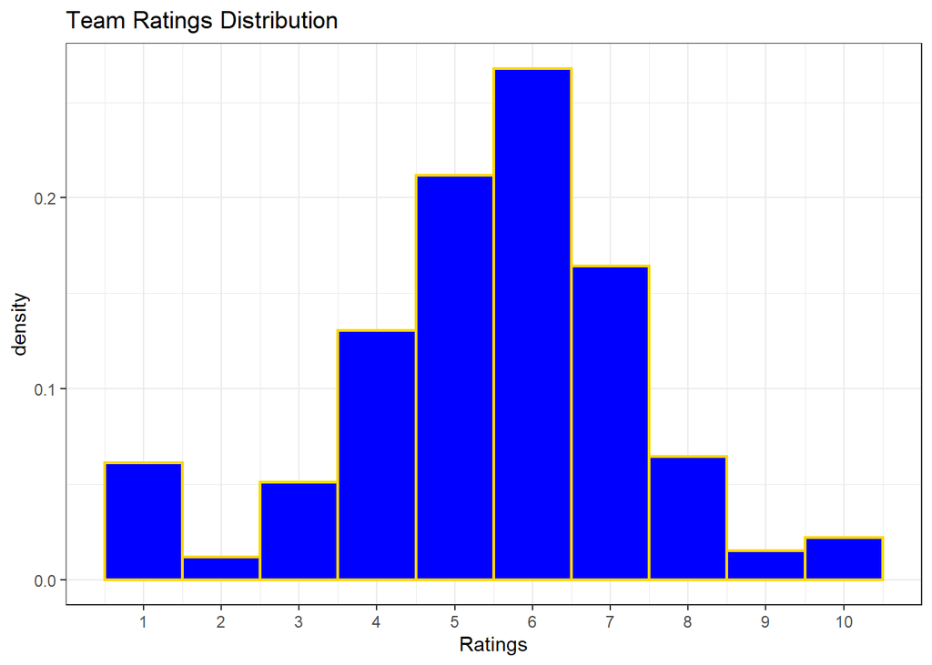

```r
md38 %>%
    ggplot(aes(x = Leicester)) +
    geom_histogram(aes(y = ..density..),binwidth = 1,
                   fill = "blue", color = "gold", size = 0.8) +
    labs(title = "Team Ratings Distribution",
         x = "Ratings") +
    scale_x_continuous(breaks = 1:10) +
    theme_bw()
```

# The Ref

The survey does not have a 1-10 rating option for the referee, but rather a “Yes” or a “No” as an answer to *Did the ref do a good job?*

As football fans, we typically tend to hate the referee, and *VAR* has been subpar this season. But the happy occasion and the lack of dubious calls allowed the referee to get many *Yes* ratings for this match.

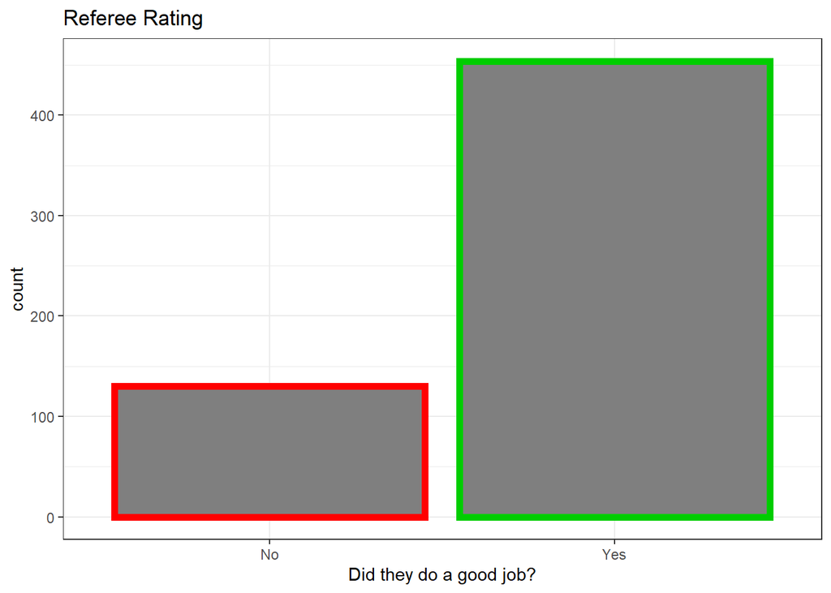

```r
subset(md38, !is.na(Referee)) %>%
    ggplot(aes(x = factor(Referee))) +
    geom_bar(fill = "grey50", color = c("red", "green3"), size = 2) +
    labs(title = "Referee Rating",
         x = "Did they do a good job?") +
    theme_bw()
```